# Aplied Statistics Project

José Pinto - 201603713

5/1/2020

## Objective

The objective of this project is to, using linear regression, try to predict the presence  
or absence of cardiovascular disease in a particular individual.

With that goal in mind a dataset was obtained containing several features of theoretical  
significance.

## Dateset description

The dataset we will be using is the cardiovascular disease dataset hosted in kaggle.  
https://www.kaggle.com/sulianova/cardiovascular-disease-dataset/data

The dataset is comprised of about 70000 records of patient data, 11 features and one  
target variable.

The features in the dataset are in a few types, whith those being, objective(factual information),  
examination(resulting of an exam) or subjective(given by the patient). The type of each  
feature will be presented further down.

All values were colected at the moment of medical examination

Note: The source of the dataset could not be verified, as such any results and conclusions  
must be carefully analised and its validity can not be fully trusted.

## Dateset import and display

```r
library(readr)
cardio_train <- read_delim("C:/Users/zé/Desktop/programação/R/EA/cardio_train.csv",
                           ";", escape_double = FALSE, trim_ws = TRUE)
knitr::kable(head(cardio_train), caption = "Cardiovascular dataset", floating.environment="sidewaystable")
```

Cardiovascular dataset

| id | age | gender | height | weight | ap_hi | ap_lo | cholesterol | gluc | smoke | alco | active | cardio |
| --- | --- | --- | --- | --- | --- | --- | --- | --- | --- | --- | --- | --- |
| 0 | 18393 | 2 | 168 | 62 | 110 | 80 | 1 | 1 | 0 | 0 | 1 | 0 |
| 1 | 20228 | 1 | 156 | 85 | 140 | 90 | 3 | 1 | 0 | 0 | 1 | 1 |
| 2 | 18857 | 1 | 165 | 64 | 130 | 70 | 3 | 1 | 0 | 0 | 0 | 1 |
| 3 | 17623 | 2 | 169 | 82 | 150 | 100 | 1 | 1 | 0 | 0 | 1 | 1 |
| 4 | 17474 | 1 | 156 | 56 | 100 | 60 | 1 | 1 | 0 | 0 | 0 | 0 |
| 8 | 21914 | 1 | 151 | 67 | 120 | 80 | 2 | 2 | 0 | 0 | 0 | 0 |

## Feature descriptions

age: The age in days of the person (objective feature), integer value  
height: The height in cm of the person(objective feature), integer value  
weight: The weight in kg of the person(objective feature), float value  
gender: The gender of the individual(objective feature), integer value with categorical  
meaning – 1-women 2-men.  
ap-hi: systolic blood pressure(examination feature), integer value  
ap-lo: diastolic blood pressure(examination feature), integer value  
cholesterol: cholesterol levels of the person(examination feature), integer value with  
categorical meaning – 1-normal 2-above normal 3-well above normal  
gluc: glucose levels of the person(examination feature), integer value with categorical  
meaning – 1-normal 2-above normal 3-well above normal  
smoke: wether or not the person smokes(subjective feature), boolean value – 0-does not smoke  
1-smokes  
alco: wether or not person consumes alcoolic beverages(subjective feature), boolean value  
0-no intake 1-intake  
active: wether or not person performs physical activity(subjective feature), boolean value  
0-no activity 1-activity

### Target variable

cardio: presence or absence of cardiovascular disease, boolean variable, 0-no disease 1-disease

The dataset also has an index row, this will now be removed.

```r
cardio_train = cardio_train[2:13]
```

## Means, median, quantiles, min and max

```r
summary(cardio_train)
```

```
##       age            gender         height          weight
##  Min.   :10798   Min.   :1.00   Min.   : 55.0   Min.   : 10.00
##  1st Qu.:17664   1st Qu.:1.00   1st Qu.:159.0   1st Qu.: 65.00
##  Median :19703   Median :1.00   Median :165.0   Median : 72.00
##  Mean   :19469   Mean   :1.35   Mean   :164.4   Mean   : 74.21
##  3rd Qu.:21327   3rd Qu.:2.00   3rd Qu.:170.0   3rd Qu.: 82.00
##  Max.   :23713   Max.   :2.00   Max.   :250.0   Max.   :200.00
##      ap_hi             ap_lo           cholesterol         gluc
##  Min.   : -150.0   Min.   :  -70.00   Min.   :1.000   Min.   :1.000
##  1st Qu.:  120.0   1st Qu.:   80.00   1st Qu.:1.000   1st Qu.:1.000
##  Median :  120.0   Median :   80.00   Median :1.000   Median :1.000
##  Mean   :  128.8   Mean   :   96.63   Mean   :1.367   Mean   :1.226
##  3rd Qu.:  140.0   3rd Qu.:   90.00   3rd Qu.:2.000   3rd Qu.:1.000
##  Max.   :16020.0   Max.   :11000.00   Max.   :3.000   Max.   :3.000
##      smoke              alco             active           cardio
##  Min.   :0.00000   Min.   :0.00000   Min.   :0.0000   Min.   :0.0000
##  1st Qu.:0.00000   1st Qu.:0.00000   1st Qu.:1.0000   1st Qu.:0.0000
##  Median :0.00000   Median :0.00000   Median :1.0000   Median :0.0000
##  Mean   :0.08813   Mean   :0.05377   Mean   :0.8037   Mean   :0.4997
##  3rd Qu.:0.00000   3rd Qu.:0.00000   3rd Qu.:1.0000   3rd Qu.:1.0000
##  Max.   :1.00000   Max.   :1.00000   Max.   :1.0000   Max.   :1.0000
```

## Variance

```r
var(cardio_train$age)
```

```
## [1] 6087331
```

```r
var(cardio_train$gender)
```

```
## [1] 0.2273745
```

```r
var(cardio_train$height)
```

```
## [1] 67.40617
```

```r
var(cardio_train$weight)
```

```
## [1] 207.2378
```

```r
var(cardio_train$ap_hi)
```

```
## [1] 23719.52
```

```r
var(cardio_train$ap_lo)
```

```
## [1] 35521.89
```

```r
var(cardio_train$cholesterol)
```

```
## [1] 0.4627405
```

```r
var(cardio_train$gluc)
```

```
## [1] 0.3274933
```

```r
var(cardio_train$smoke)
```

```
## [1] 0.08036307
```

```r
var(cardio_train$alco)
```

```
## [1] 0.05088079
```

```r
var(cardio_train$active)
```

```
## [1] 0.1577512
```

```r
var(cardio_train$cardio)
```

```
## [1] 0.2500035
```

## Features boxplots

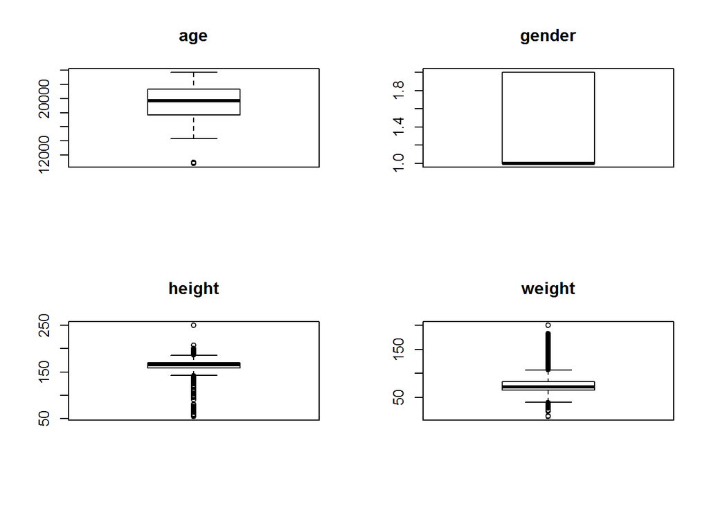

```r
par(mfrow=c(2,2))
boxplot(cardio_train$age,main="age")
boxplot(cardio_train$gender,main="gender")
boxplot(cardio_train$height,main="height")
boxplot(cardio_train$weight,main="weight")
```

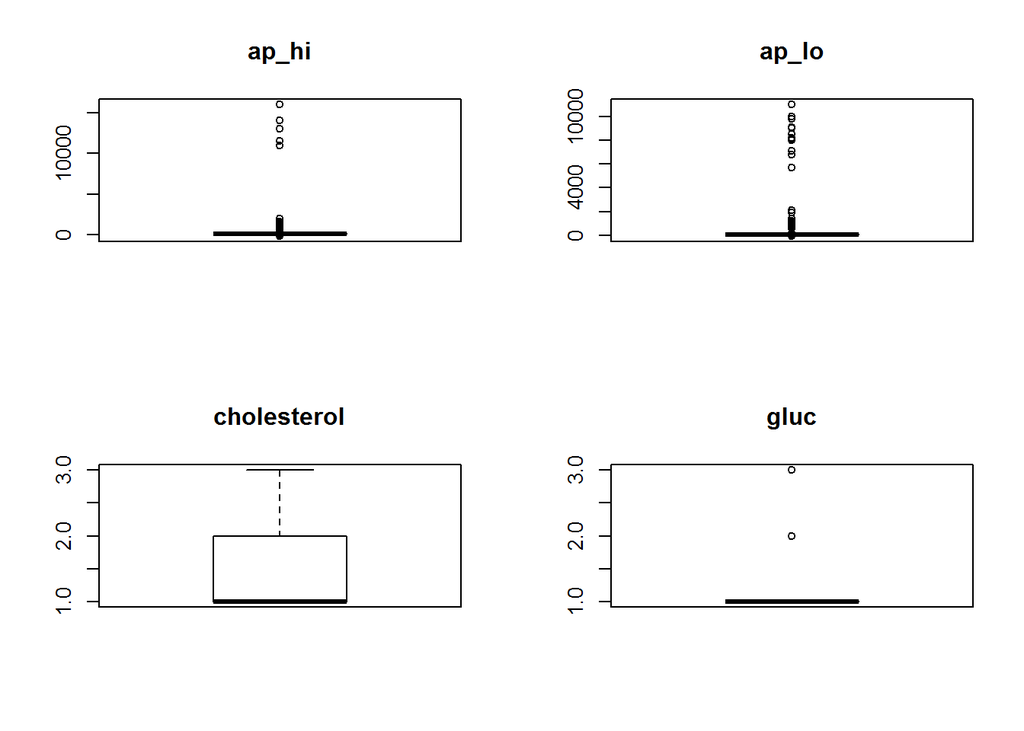

```r
boxplot(cardio_train$ap_hi,main="ap_hi")
boxplot(cardio_train$ap_lo,main="ap_lo")
boxplot(cardio_train$cholesterol,main="cholesterol")
boxplot(cardio_train$gluc,main="gluc")
```

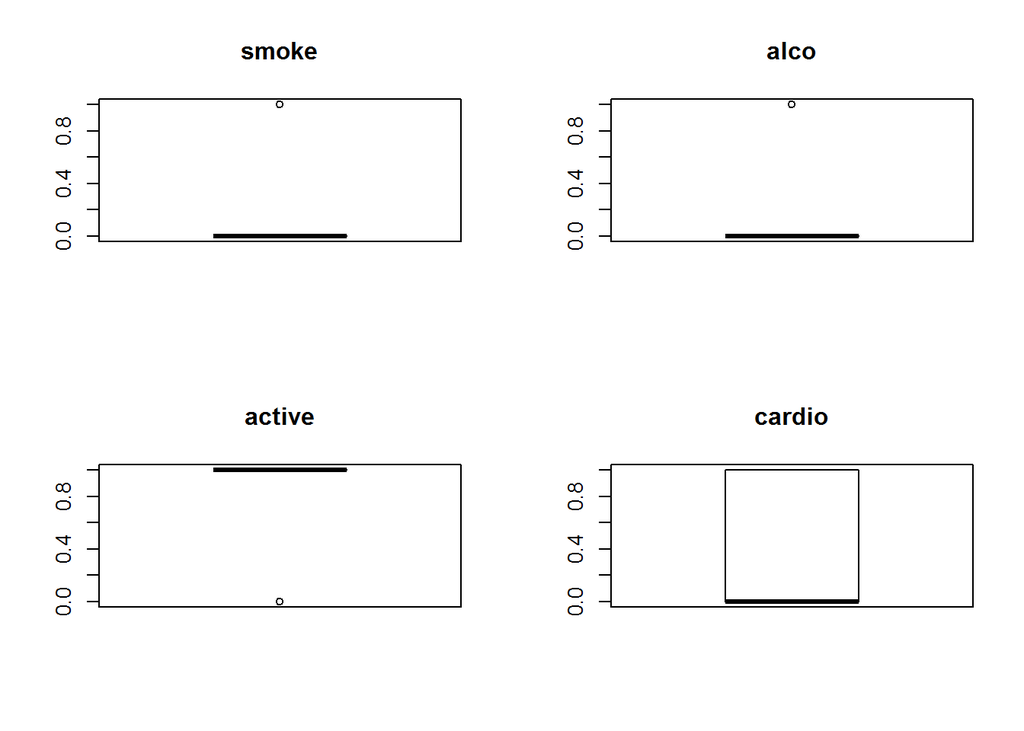

```r
boxplot(cardio_train$smoke,main="smoke")
boxplot(cardio_train$alco,main="alco")
boxplot(cardio_train$active,main="active")
boxplot(cardio_train$cardio,main="cardio")
```

The obviously wrong values spotted in this step will be processed and likely removed at a later time.

## Features histograms

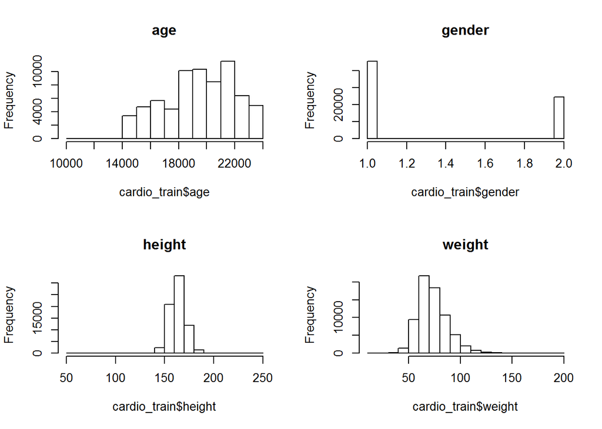

```r
par(mfrow=c(2,2))
hist(cardio_train$age,main="age")
hist(cardio_train$gender,main="gender")
hist(cardio_train$height,main="height")
hist(cardio_train$weight,main="weight")
```

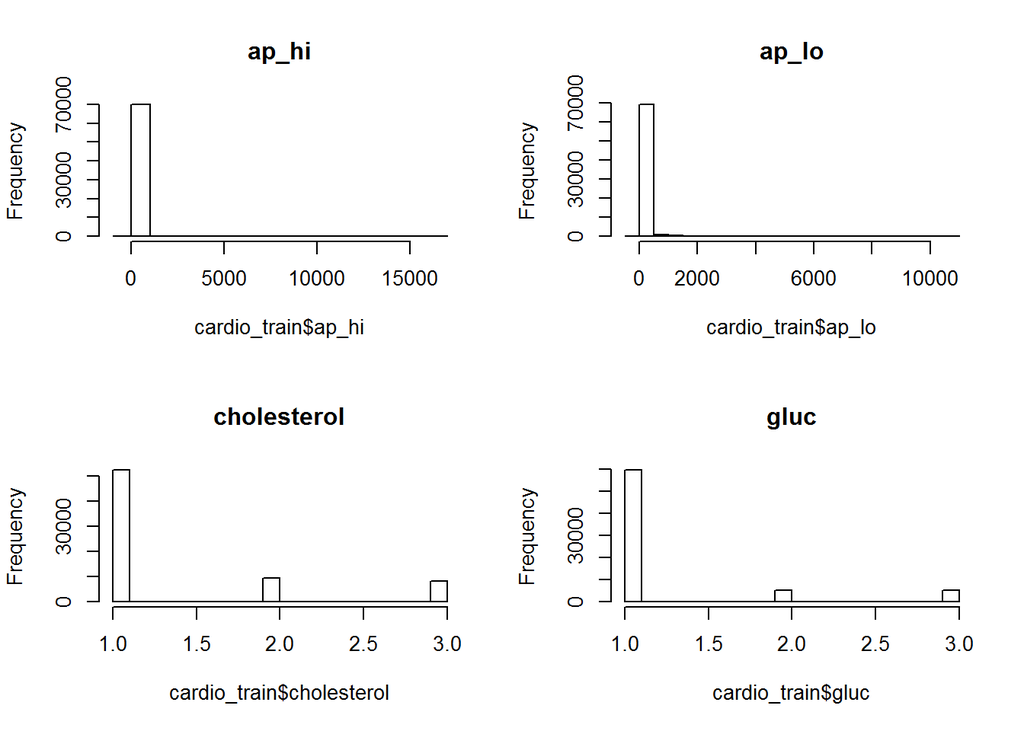

```r
hist(cardio_train$ap_hi,main="ap_hi")
hist(cardio_train$ap_lo,main="ap_lo")
hist(cardio_train$cholesterol,main="cholesterol")
hist(cardio_train$gluc,main="gluc")
```

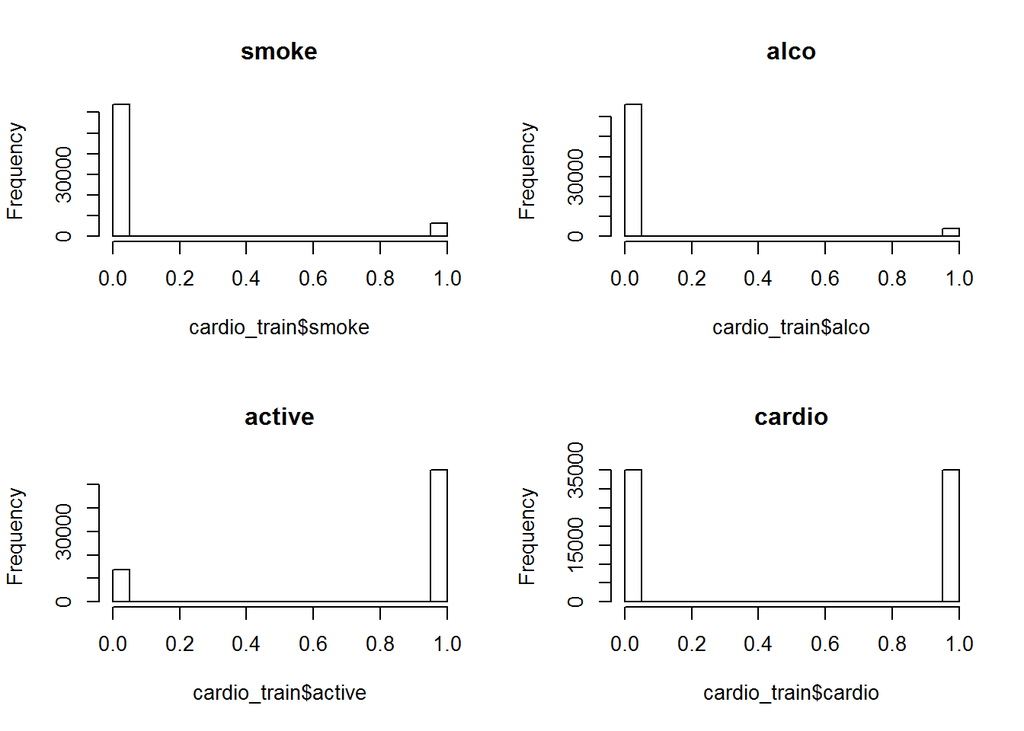

```r
hist(cardio_train$smoke,main="smoke")
hist(cardio_train$alco,main="alco")
hist(cardio_train$active,main="active")
hist(cardio_train$cardio,main="cardio")
```

We would not expect that the amount of people with cardiovascular diseases to be almost identical  
to the amount of those without, as such we can conclude that the data as almost certainly sampled to  
create an unbiased and equal distribution of this property.  
We would also expect that from random sampling the amount of men and women would be quite close, wich  
is not the case, with a lot more women than men.  
None of the features seem to follow a normal distribution wich may prove a problem. However due to the  
sample size such a problem is likely to be either mitigated or practically inexistent.  
The extremely skewed distriution of ap_hi, ap_lo, cholesterol and gluc might cause bias in the data.

## Features normality test(qqnorm, test)

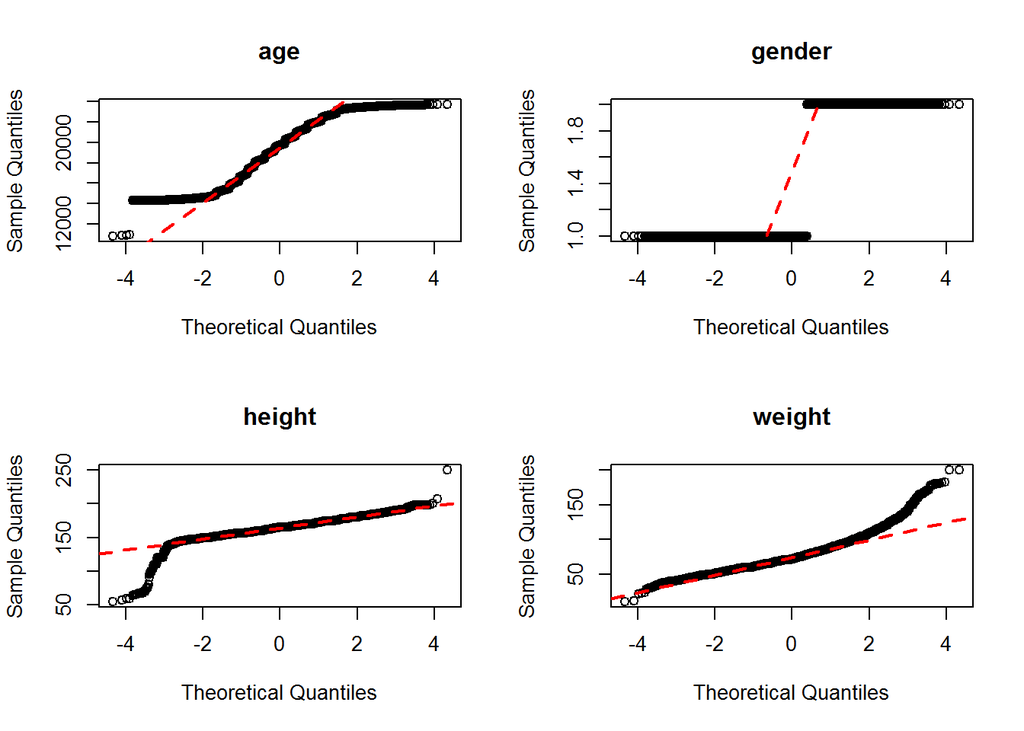

```r
par(mfrow=c(2,2))
qqnorm(cardio_train$age,main="age"); qqline(cardio_train$age, col = 2,lwd=2,lty=2)
qqnorm(cardio_train$gender,main="gender"); qqline(cardio_train$gender, col = 2,lwd=2,lty=2)
qqnorm(cardio_train$height,main="height"); qqline(cardio_train$height, col = 2,lwd=2,lty=2)
qqnorm(cardio_train$weight,main="weight"); qqline(cardio_train$weight, col = 2,lwd=2,lty=2)
```

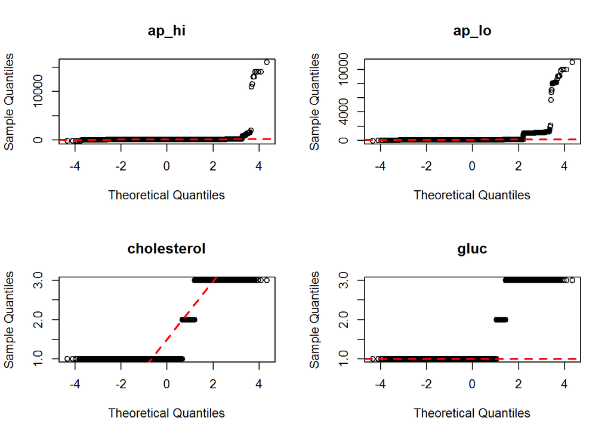

```r
qqnorm(cardio_train$ap_hi,main="ap_hi"); qqline(cardio_train$ap_hi, col = 2,lwd=2,lty=2)
qqnorm(cardio_train$ap_lo,main="ap_lo"); qqline(cardio_train$ap_lo, col = 2,lwd=2,lty=2)
qqnorm(cardio_train$cholesterol,main="cholesterol"); qqline(cardio_train$cholesterol, col = 2,lwd=2,lty=2)
qqnorm(cardio_train$gluc,main="gluc"); qqline(cardio_train$gluc, col = 2,lwd=2,lty=2)
```

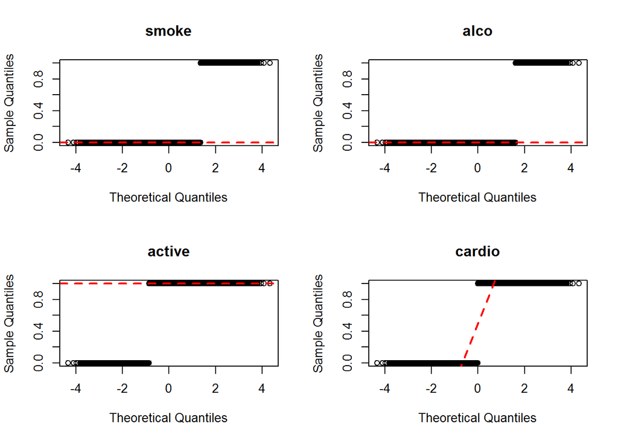

```r
qqnorm(cardio_train$smoke,main="smoke"); qqline(cardio_train$smoke, col = 2,lwd=2,lty=2)
qqnorm(cardio_train$alco,main="alco"); qqline(cardio_train$alco, col = 2,lwd=2,lty=2)
qqnorm(cardio_train$active,main="active"); qqline(cardio_train$active, col = 2,lwd=2,lty=2)
qqnorm(cardio_train$cardio,main="cardio"); qqline(cardio_train$cardio, col = 2,lwd=2,lty=2)
library(tseries)
```

```r
jarque.bera.test(cardio_train$age)
```

```
##
##  Jarque Bera Test
##
## data:  cardio_train$age
## X-squared = 3077.7, df = 2, p-value < 2.2e-16
```

```r
jarque.bera.test(cardio_train$gender)
```

```
##
##  Jarque Bera Test
##
## data:  cardio_train$gender
## X-squared = 12129, df = 2, p-value < 2.2e-16
```

```r
jarque.bera.test(cardio_train$height)
```

```
##
##  Jarque Bera Test
##
## data:  cardio_train$height
## X-squared = 188827, df = 2, p-value < 2.2e-16
```

```r
jarque.bera.test(cardio_train$weight)
```

```
##
##  Jarque Bera Test
##
## data:  cardio_train$weight
## X-squared = 31463, df = 2, p-value < 2.2e-16
```

```r
jarque.bera.test(cardio_train$ap_hi)
```

```
##
##  Jarque Bera Test
##
## data:  cardio_train$ap_hi
## X-squared = 1.6765e+11, df = 2, p-value < 2.2e-16
```

```r
jarque.bera.test(cardio_train$ap_lo)
```

```
##
##  Jarque Bera Test
##
## data:  cardio_train$ap_lo
## X-squared = 5941444816, df = 2, p-value < 2.2e-16
```

```r
jarque.bera.test(cardio_train$cholesterol)
```

```
##
##  Jarque Bera Test
##
## data:  cardio_train$cholesterol
## X-squared = 32267, df = 2, p-value < 2.2e-16
```

```r
jarque.bera.test(cardio_train$gluc)
```

```
##
##  Jarque Bera Test
##
## data:  cardio_train$gluc
## X-squared = 120833, df = 2, p-value < 2.2e-16
```

```r
jarque.bera.test(cardio_train$smoke)
```

```
##
##  Jarque Bera Test
##
## data:  cardio_train$smoke
## X-squared = 219614, df = 2, p-value < 2.2e-16
```

```r
jarque.bera.test(cardio_train$alco)
```

```
##
##  Jarque Bera Test
##
## data:  cardio_train$alco
## X-squared = 726395, df = 2, p-value < 2.2e-16
```

```r
jarque.bera.test(cardio_train$active)
```

```
##
##  Jarque Bera Test
##
## data:  cardio_train$active
## X-squared = 27626, df = 2, p-value < 2.2e-16
```

```r
jarque.bera.test(cardio_train$cardio)
```

```
##
##  Jarque Bera Test
##
## data:  cardio_train$cardio
## X-squared = 11667, df = 2, p-value < 2.2e-16
```

From the plots and tests we can conclude that no feature is normaly distributed(or even close to it)  
wich will make the analisis more complicated.

Other normality tests were tried, however all of them returned an error due to sample size, as such  
this one(the only one that worked) was used.

## Feature correlations

```r
cor(cardio_train)
```

```
##                      age       gender       height      weight
## age          1.000000000 -0.022810652 -0.081515349  0.05368404
## gender      -0.022810652  1.000000000  0.499033428  0.15540564
## height      -0.081515349  0.499033428  1.000000000  0.29096783
## weight       0.053684043  0.155405640  0.290967835  1.00000000
## ap_hi        0.020764319  0.006005309  0.005487764  0.03070221
## ap_lo        0.017647434  0.015253971  0.006150467  0.04370977
## cholesterol  0.154423742 -0.035821413 -0.050225952  0.14176791
## gluc         0.098702772 -0.020491035 -0.018594670  0.10685726
## smoke       -0.047632810  0.338135136  0.187989399  0.06778047
## alco        -0.029722867  0.170966429  0.094418693  0.06711284
## active      -0.009927354  0.005865669 -0.006569547 -0.01686675
## cardio       0.238159227  0.008109492 -0.010821058  0.18165956
##                     ap_hi       ap_lo  cholesterol         gluc
## age          2.076432e-02 0.017647434  0.154423742  0.098702772
## gender       6.005309e-03 0.015253971 -0.035821413 -0.020491035
## height       5.487764e-03 0.006150467 -0.050225952 -0.018594670
## weight       3.070221e-02 0.043709773  0.141767906  0.106857265
## ap_hi        1.000000e+00 0.016085513  0.023777922  0.011840678
## ap_lo        1.608551e-02 1.000000000  0.024019290  0.010805666
## cholesterol  2.377792e-02 0.024019290  1.000000000  0.451577524
## gluc         1.184068e-02 0.010805666  0.451577524  1.000000000
## smoke       -9.220248e-04 0.005186130  0.010354415 -0.004756483
## alco         1.408333e-03 0.010601240  0.035760386  0.011245771
## active      -3.300248e-05 0.004780258  0.009911297 -0.006769518
## cardio       5.447505e-02 0.065718696  0.221147274  0.089306887
##                     smoke         alco        active       cardio
## age         -0.0476328098 -0.029722867 -9.927354e-03  0.238159227
## gender       0.3381351364  0.170966429  5.865669e-03  0.008109492
## height       0.1879893994  0.094418693 -6.569547e-03 -0.010821058
## weight       0.0677804655  0.067112841 -1.686675e-02  0.181659562
## ap_hi       -0.0009220248  0.001408333 -3.300248e-05  0.054475054
## ap_lo        0.0051861304  0.010601240  4.780258e-03  0.065718696
## cholesterol  0.0103544151  0.035760386  9.911297e-03  0.221147274
## gluc        -0.0047564831  0.011245771 -6.769518e-03  0.089306887
## smoke        1.0000000000  0.340093768  2.585797e-02 -0.015485936
## alco         0.3400937679  1.000000000  2.547583e-02 -0.007330232
## active       0.0258579688  0.025475829  1.000000e+00 -0.035653248
## cardio      -0.0154859357 -0.007330232 -3.565325e-02  1.000000000
```

We can observe that no two features are highly correlated with each other, with the correlation bettwen  
height and gender being the highest(0.5), wich on one hand will facilitate the analisis of the results, but  
on the othe, given that there is allways little correlation bettwen the features and target variable,  
obtaining good results may prove difficult.

## Features scatterplots

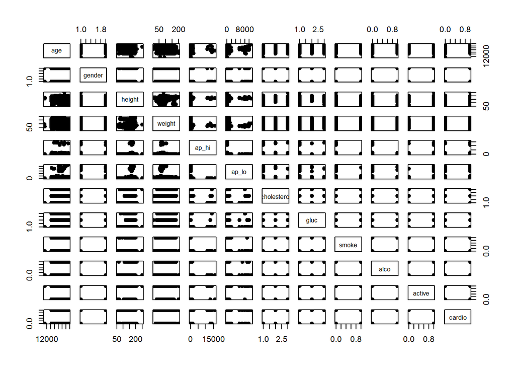

```r
pairs(cardio_train, pch = 19)
```

Due to the presence of a lot of categorical and binary variables most of the plots don’t hold much meaning.  
There is however an interesting aspect of the data, in a lot of the plots, the points seem to get divided  
into two distinct groups. The meaning of this cannot be affered at this time, however this will be something  
to take into consideration as the work develops.

## Response by value of categorical features

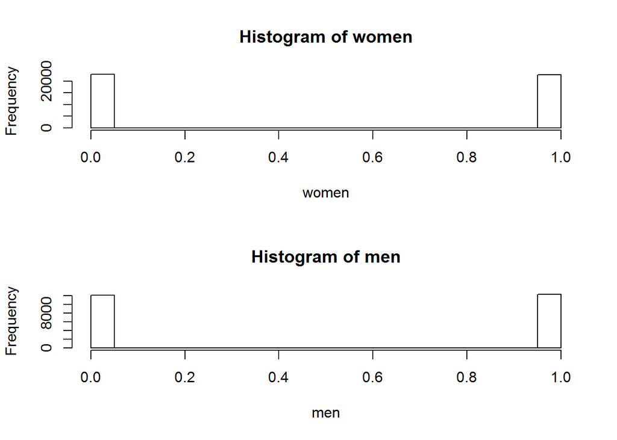

```r
par(mfrow=c(2,1))
women =  cardio_train[which(cardio_train$gender==1),]$cardio
men =  cardio_train[which(cardio_train$gender==2),]$cardio
hist(women, pch = 19)
hist(men, pch = 19)
```

The results are almost exactly the same for men and women, as such this feature does not hold much information.

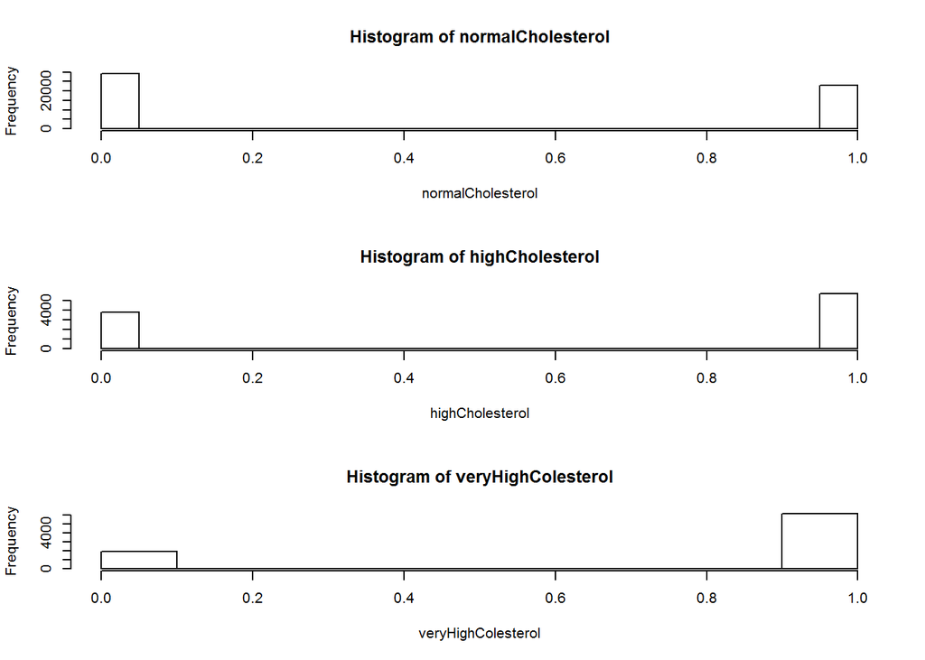

```r
par(mfrow=c(3,1))
normalCholesterol =  cardio_train[which(cardio_train$cholesterol==1),]$cardio
highCholesterol =  cardio_train[which(cardio_train$cholesterol==2),]$cardio
veryHighColesterol =  cardio_train[which(cardio_train$cholesterol==3),]$cardio
hist(normalCholesterol, pch = 19)
hist(highCholesterol, pch = 19)
hist(veryHighColesterol, pch = 19)
```

The results are as we would theoritically expect, with higher amounts of cholesterol equating to higher chance  
of cardiovascular disease.

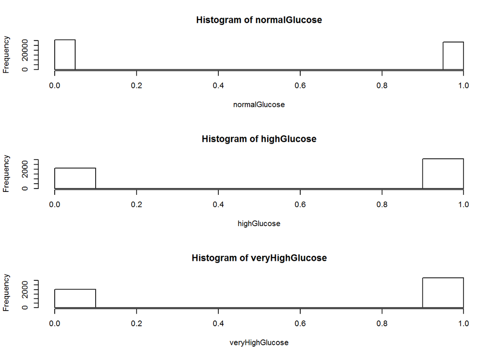

```r
par(mfrow=c(3,1))
normalGlucose =  cardio_train[which(cardio_train$gluc==1),]$cardio
highGlucose =  cardio_train[which(cardio_train$gluc==2),]$cardio
veryHighGlucose =  cardio_train[which(cardio_train$gluc==3),]$cardio
hist(normalGlucose, pch = 19)
hist(highGlucose, pch = 19)
hist(veryHighGlucose, pch = 19)
```

The results are as we would theoritically expect, with higher amounts of glucose equating to higher chance  
of cardiovascular disease.

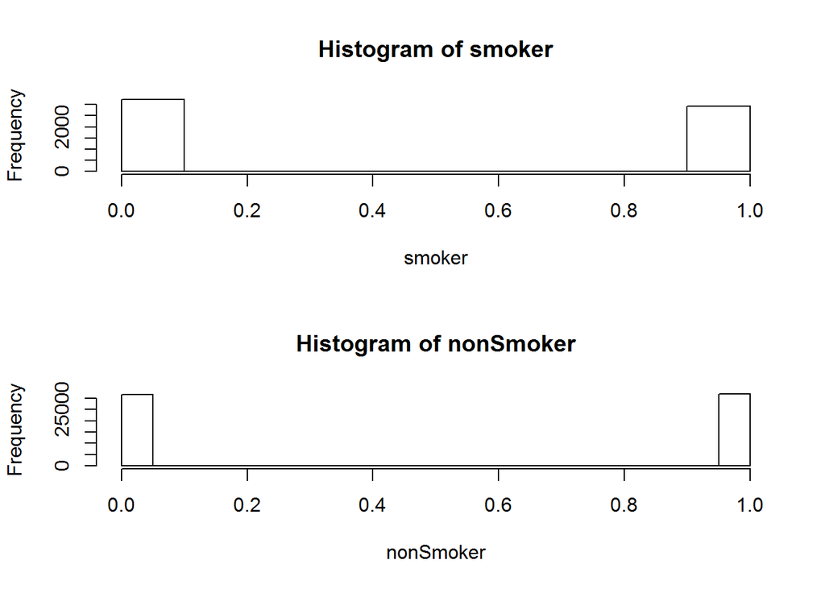

```r
par(mfrow=c(2,1))
nonSmoker =  cardio_train[which(cardio_train$smoke==0),]$cardio
smoker =  cardio_train[which(cardio_train$smoke==1),]$cardio
hist(smoker, pch = 19)
hist(nonSmoker, pch = 19)
```

The results are almost exactly the same for smokers and non smokers, as such this feature does not hold much  
information. This however goes against what is to be expected.

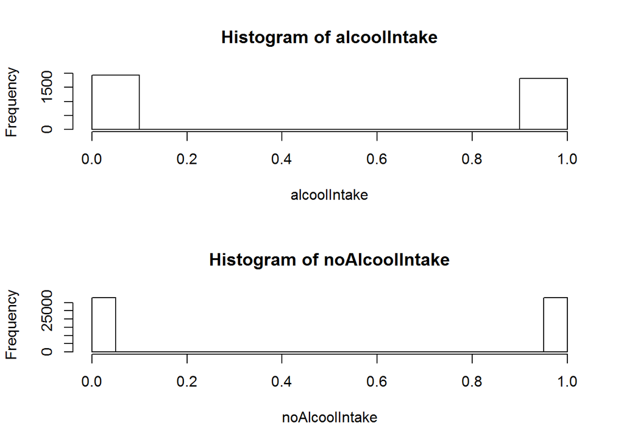

```r
par(mfrow=c(2,1))
noAlcoolIntake =  cardio_train[which(cardio_train$alco==0),]$cardio
alcoolIntake =  cardio_train[which(cardio_train$alco==1),]$cardio
hist(alcoolIntake, pch = 19)
hist(noAlcoolIntake, pch = 19)
```

The results are almost exactly the same for individuals who consume alcool as to those who do not, as such this  
feature does not hold much information. This however goes against what is to be expected.

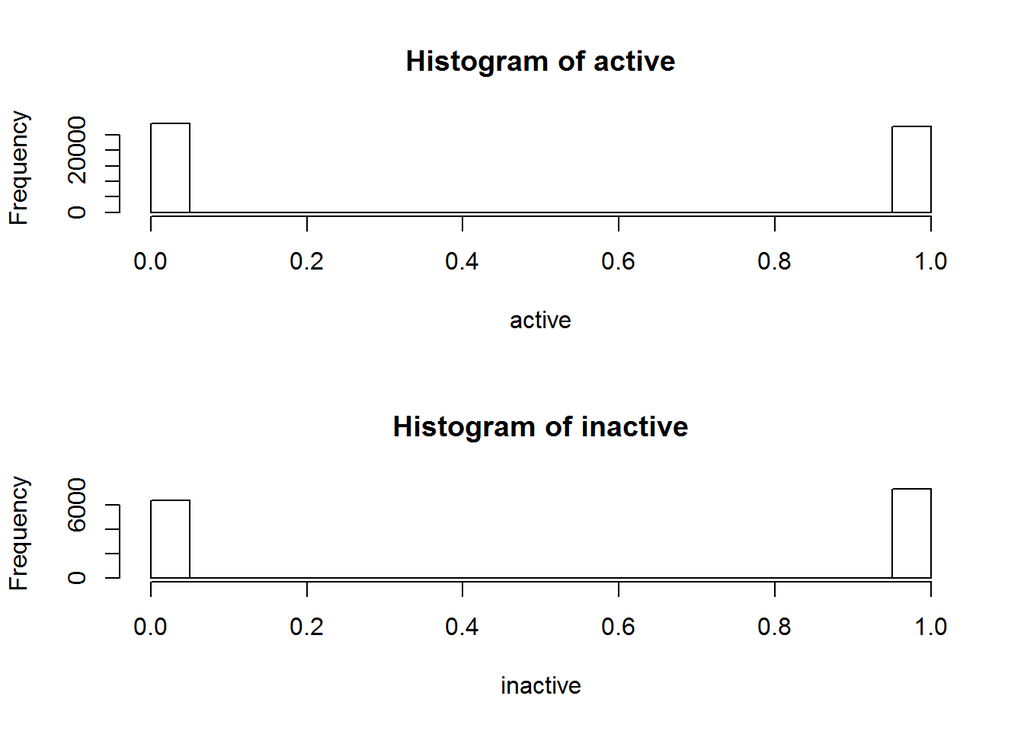

```r
par(mfrow=c(2,1))
inactive =  cardio_train[which(cardio_train$active==0),]$cardio
active =  cardio_train[which(cardio_train$active==1),]$cardio
hist(active, pch = 19)
hist(inactive, pch = 19)
```

The results are almost exactly the same for for individuals that are active as well as those who are not as  
such this feature does not hold much information. This however goes against what is to be expected.

## Simple processing

Some problems have been identified, namely the obviously wrong values in ap_hi and ap_lo, wich will now be  
taken care of.

```r
cardio_train_clean = cardio_train[which(!(cardio_train$ap_hi>500|cardio_train$ap_lo>500|cardio_train$ap_hi<0|cardio_train$ap_lo<0)),]
```

As other outliers have reasonable values they will be kept for now, and possibly removed later if they cause  
problems.

We will also perform changes in some categorical variables.  
For gender we will change the values from 1-women, 2-men to a more standard 0-women, 1-men.  
For cholesterol we will turn the column type into factor.  
For gluc we will turn the column type into factor.

```r
cardio_train_clean$gender = cardio_train_clean$gender-1
```

```r
cardio_train_clean$cholesterol = as.factor(cardio_train_clean$cholesterol)
```

```r
cardio_train_clean$gluc = as.factor(cardio_train_clean$gluc)
```

## Null model

Now we will create the empty, null, model.

```r
nullModel = lm(cardio_train_clean$cardio ~ 1)
nullModel
```

```
##
## Call:
## lm(formula = cardio_train_clean$cardio ~ 1)
##
## Coefficients:
## (Intercept)
##      0.4949
```

```r
anova(nullModel)
```

```
## Analysis of Variance Table
##
## Response: cardio_train_clean$cardio
##              Df Sum Sq Mean Sq F value Pr(>F)
## Residuals 69000  17248 0.24998
```

From this model we obtained an intercept of 0.4949, wich means that the mean is 0.4949, wich in turn means  
that 49.49% of the individuals were found to have cardiovascular diseases.  
We also obtained a TSS of 17250 and a mean squared error of 0.24998

## Single model

Let’s create models with a single variable to see their impact.  
For the case of the dummie vriables, these will also be analised separatly from each other.

```r
ageModel = lm(cardio_train_clean$cardio ~ cardio_train_clean$age)
ageModel
```

```
##
## Call:
## lm(formula = cardio_train_clean$cardio ~ cardio_train_clean$age)
##
## Coefficients:
##            (Intercept)  cardio_train_clean$age
##             -4.503e-01               4.856e-05
```

```r
anova(ageModel)
```

```
## Analysis of Variance Table
##
## Response: cardio_train_clean$cardio
##                           Df  Sum Sq Mean Sq F value    Pr(>F)
## cardio_train_clean$age     1   991.3  991.26  4207.1 < 2.2e-16 ***
## Residuals              68999 16257.2    0.24
## ---
## Signif. codes:  0 '***' 0.001 '**' 0.01 '*' 0.05 '.' 0.1 ' ' 1
```

```r
anova(nullModel,ageModel)
```

```
## Analysis of Variance Table
##
## Model 1: cardio_train_clean$cardio ~ 1
## Model 2: cardio_train_clean$cardio ~ cardio_train_clean$age
##   Res.Df   RSS Df Sum of Sq      F    Pr(>F)
## 1  69000 17248
## 2  68999 16257  1    991.26 4207.1 < 2.2e-16 ***
## ---
## Signif. codes:  0 '***' 0.001 '**' 0.01 '*' 0.05 '.' 0.1 ' ' 1
```

```r
genderModel = lm(cardio_train_clean$cardio ~ cardio_train_clean$gender)
genderModel
```

```
##
## Call:
## lm(formula = cardio_train_clean$cardio ~ cardio_train_clean$gender)
##
## Coefficients:
##               (Intercept)  cardio_train_clean$gender
##                  0.492123                   0.007898
```

```r
anova(genderModel)
```

```
## Analysis of Variance Table
##
## Response: cardio_train_clean$cardio
##                              Df Sum Sq Mean Sq F value  Pr(>F)
## cardio_train_clean$gender     1      1 0.97751  3.9105 0.04799 *
## Residuals                 68999  17248 0.24997
## ---
## Signif. codes:  0 '***' 0.001 '**' 0.01 '*' 0.05 '.' 0.1 ' ' 1
```

```r
anova(nullModel,genderModel)
```

```
## Analysis of Variance Table
##
## Model 1: cardio_train_clean$cardio ~ 1
## Model 2: cardio_train_clean$cardio ~ cardio_train_clean$gender
##   Res.Df   RSS Df Sum of Sq      F  Pr(>F)
## 1  69000 17248
## 2  68999 17248  1   0.97751 3.9105 0.04799 *
## ---
## Signif. codes:  0 '***' 0.001 '**' 0.01 '*' 0.05 '.' 0.1 ' ' 1
```

```r
heightModel = lm(cardio_train_clean$cardio ~ cardio_train_clean$height)
heightModel
```

```
##
## Call:
## lm(formula = cardio_train_clean$cardio ~ cardio_train_clean$height)
##
## Coefficients:
##               (Intercept)  cardio_train_clean$height
##                 0.5990059                 -0.0006335
```

```r
anova(heightModel)
```

```
## Analysis of Variance Table
##
## Response: cardio_train_clean$cardio
##                              Df  Sum Sq Mean Sq F value   Pr(>F)
## cardio_train_clean$height     1     1.9 1.86411  7.4578 0.006318 **
## Residuals                 68999 17246.6 0.24995
## ---
## Signif. codes:  0 '***' 0.001 '**' 0.01 '*' 0.05 '.' 0.1 ' ' 1
```

```r
anova(nullModel,heightModel)
```

```
## Analysis of Variance Table
##
## Model 1: cardio_train_clean$cardio ~ 1
## Model 2: cardio_train_clean$cardio ~ cardio_train_clean$height
##   Res.Df   RSS Df Sum of Sq      F   Pr(>F)
## 1  69000 17248
## 2  68999 17247  1    1.8641 7.4578 0.006318 **
## ---
## Signif. codes:  0 '***' 0.001 '**' 0.01 '*' 0.05 '.' 0.1 ' ' 1
```

```r
weightModel = lm(cardio_train_clean$cardio ~ cardio_train_clean$weight)
weightModel
```

```
##
## Call:
## lm(formula = cardio_train_clean$cardio ~ cardio_train_clean$weight)
##
## Coefficients:
##               (Intercept)  cardio_train_clean$weight
##                  0.029371                   0.006281
```

```r
anova(weightModel)
```

```
## Analysis of Variance Table
##
## Response: cardio_train_clean$cardio
##                              Df  Sum Sq Mean Sq F value    Pr(>F)
## cardio_train_clean$weight     1   558.8  558.80  2310.2 < 2.2e-16 ***
## Residuals                 68999 16689.6    0.24
## ---
## Signif. codes:  0 '***' 0.001 '**' 0.01 '*' 0.05 '.' 0.1 ' ' 1
```

```r
anova(nullModel,weightModel)
```

```
## Analysis of Variance Table
##
## Model 1: cardio_train_clean$cardio ~ 1
## Model 2: cardio_train_clean$cardio ~ cardio_train_clean$weight
##   Res.Df   RSS Df Sum of Sq      F    Pr(>F)
## 1  69000 17248
## 2  68999 16690  1     558.8 2310.2 < 2.2e-16 ***
## ---
## Signif. codes:  0 '***' 0.001 '**' 0.01 '*' 0.05 '.' 0.1 ' ' 1
```

```r
weightModel = lm(cardio_train_clean$cardio ~ cardio_train_clean$weight)
weightModel
```

```
##
## Call:
## lm(formula = cardio_train_clean$cardio ~ cardio_train_clean$weight)
##
## Coefficients:
##               (Intercept)  cardio_train_clean$weight
##                  0.029371                   0.006281
```

```r
anova(weightModel)
```

```
## Analysis of Variance Table
##
## Response: cardio_train_clean$cardio
##                              Df  Sum Sq Mean Sq F value    Pr(>F)
## cardio_train_clean$weight     1   558.8  558.80  2310.2 < 2.2e-16 ***
## Residuals                 68999 16689.6    0.24
## ---
## Signif. codes:  0 '***' 0.001 '**' 0.01 '*' 0.05 '.' 0.1 ' ' 1
```

```r
anova(nullModel,weightModel)
```

```
## Analysis of Variance Table
##
## Model 1: cardio_train_clean$cardio ~ 1
## Model 2: cardio_train_clean$cardio ~ cardio_train_clean$weight
##   Res.Df   RSS Df Sum of Sq      F    Pr(>F)
## 1  69000 17248
## 2  68999 16690  1     558.8 2310.2 < 2.2e-16 ***
## ---
## Signif. codes:  0 '***' 0.001 '**' 0.01 '*' 0.05 '.' 0.1 ' ' 1
```

```r
ap_hiModel = lm(cardio_train_clean$cardio ~ cardio_train_clean$ap_hi)
ap_hiModel
```

```
##
## Call:
## lm(formula = cardio_train_clean$cardio ~ cardio_train_clean$ap_hi)
##
## Coefficients:
##              (Intercept)  cardio_train_clean$ap_hi
##                 -0.92984                   0.01128
```

```r
anova(ap_hiModel)
```

```
## Analysis of Variance Table
##
## Response: cardio_train_clean$cardio
##                             Df  Sum Sq Mean Sq F value    Pr(>F)
## cardio_train_clean$ap_hi     1  2765.8 2765.80   13177 < 2.2e-16 ***
## Residuals                68999 14482.6    0.21
## ---
## Signif. codes:  0 '***' 0.001 '**' 0.01 '*' 0.05 '.' 0.1 ' ' 1
```

```r
anova(nullModel,ap_hiModel)
```

```
## Analysis of Variance Table
##
## Model 1: cardio_train_clean$cardio ~ 1
## Model 2: cardio_train_clean$cardio ~ cardio_train_clean$ap_hi
##   Res.Df   RSS Df Sum of Sq     F    Pr(>F)
## 1  69000 17248
## 2  68999 14483  1    2765.8 13177 < 2.2e-16 ***
## ---
## Signif. codes:  0 '***' 0.001 '**' 0.01 '*' 0.05 '.' 0.1 ' ' 1
```

```r
ap_loModel = lm(cardio_train_clean$cardio ~ cardio_train_clean$ap_lo)
ap_loModel
```

```
##
## Call:
## lm(formula = cardio_train_clean$cardio ~ cardio_train_clean$ap_lo)
##
## Coefficients:
##              (Intercept)  cardio_train_clean$ap_lo
##                 -0.85873                   0.01664
```

```r
anova(ap_loModel)
```

```
## Analysis of Variance Table
##
## Response: cardio_train_clean$cardio
##                             Df  Sum Sq Mean Sq F value    Pr(>F)
## cardio_train_clean$ap_lo     1  1864.7 1864.69  8363.5 < 2.2e-16 ***
## Residuals                68999 15383.8    0.22
## ---
## Signif. codes:  0 '***' 0.001 '**' 0.01 '*' 0.05 '.' 0.1 ' ' 1
```

```r
anova(nullModel,ap_loModel)
```

```
## Analysis of Variance Table
##
## Model 1: cardio_train_clean$cardio ~ 1
## Model 2: cardio_train_clean$cardio ~ cardio_train_clean$ap_lo
##   Res.Df   RSS Df Sum of Sq      F    Pr(>F)
## 1  69000 17248
## 2  68999 15384  1    1864.7 8363.5 < 2.2e-16 ***
## ---
## Signif. codes:  0 '***' 0.001 '**' 0.01 '*' 0.05 '.' 0.1 ' ' 1
```

```r
cholesterolModel = lm(cardio_train_clean$cardio ~ cardio_train_clean$cholesterol)
cholesterolModel
```

```
##
## Call:
## lm(formula = cardio_train_clean$cardio ~ cardio_train_clean$cholesterol)
##
## Coefficients:
##                     (Intercept)  cardio_train_clean$cholesterol2
##                          0.4356                           0.1609
## cardio_train_clean$cholesterol3
##                          0.3272
```

```r
anova(cholesterolModel)
```

```
## Analysis of Variance Table
##
## Response: cardio_train_clean$cardio
##                                   Df  Sum Sq Mean Sq F value    Pr(>F)
## cardio_train_clean$cholesterol     2   845.5  422.76  1778.3 < 2.2e-16 ***
## Residuals                      68998 16402.9    0.24
## ---
## Signif. codes:  0 '***' 0.001 '**' 0.01 '*' 0.05 '.' 0.1 ' ' 1
```

```r
anova(nullModel,cholesterolModel)
```

```
## Analysis of Variance Table
##
## Model 1: cardio_train_clean$cardio ~ 1
## Model 2: cardio_train_clean$cardio ~ cardio_train_clean$cholesterol
##   Res.Df   RSS Df Sum of Sq      F    Pr(>F)
## 1  69000 17248
## 2  68998 16403  2    845.53 1778.3 < 2.2e-16 ***
## ---
## Signif. codes:  0 '***' 0.001 '**' 0.01 '*' 0.05 '.' 0.1 ' ' 1
```

```r
glucModel = lm(cardio_train_clean$cardio ~ cardio_train_clean$gluc)
glucModel
```

```
##
## Call:
## lm(formula = cardio_train_clean$cardio ~ cardio_train_clean$gluc)
##
## Coefficients:
##              (Intercept)  cardio_train_clean$gluc2
##                   0.4757                    0.1129
## cardio_train_clean$gluc3
##                   0.1425
```

```r
anova(glucModel)
```

```
## Analysis of Variance Table
##
## Response: cardio_train_clean$cardio
##                            Df  Sum Sq Mean Sq F value    Pr(>F)
## cardio_train_clean$gluc     2   146.1  73.066  294.78 < 2.2e-16 ***
## Residuals               68998 17102.3   0.248
## ---
## Signif. codes:  0 '***' 0.001 '**' 0.01 '*' 0.05 '.' 0.1 ' ' 1
```

```r
anova(nullModel,glucModel)
```

```
## Analysis of Variance Table
##
## Model 1: cardio_train_clean$cardio ~ 1
## Model 2: cardio_train_clean$cardio ~ cardio_train_clean$gluc
##   Res.Df   RSS Df Sum of Sq      F    Pr(>F)
## 1  69000 17248
## 2  68998 17102  2    146.13 294.78 < 2.2e-16 ***
## ---
## Signif. codes:  0 '***' 0.001 '**' 0.01 '*' 0.05 '.' 0.1 ' ' 1
```

```r
smokeModel = lm(cardio_train_clean$cardio ~ cardio_train_clean$smoke)
smokeModel
```

```
##
## Call:
## lm(formula = cardio_train_clean$cardio ~ cardio_train_clean$smoke)
##
## Coefficients:
##              (Intercept)  cardio_train_clean$smoke
##                  0.49741                  -0.02883
```

```r
anova(smokeModel)
```

```
## Analysis of Variance Table
##
## Response: cardio_train_clean$cardio
##                             Df  Sum Sq Mean Sq F value  Pr(>F)
## cardio_train_clean$smoke     1     4.6  4.5967  18.393 1.8e-05 ***
## Residuals                68999 17243.8  0.2499
## ---
## Signif. codes:  0 '***' 0.001 '**' 0.01 '*' 0.05 '.' 0.1 ' ' 1
```

```r
anova(nullModel,smokeModel)
```

```
## Analysis of Variance Table
##
## Model 1: cardio_train_clean$cardio ~ 1
## Model 2: cardio_train_clean$cardio ~ cardio_train_clean$smoke
##   Res.Df   RSS Df Sum of Sq      F  Pr(>F)
## 1  69000 17248
## 2  68999 17244  1    4.5967 18.393 1.8e-05 ***
## ---
## Signif. codes:  0 '***' 0.001 '**' 0.01 '*' 0.05 '.' 0.1 ' ' 1
```

```r
alcoModel = lm(cardio_train_clean$cardio ~ cardio_train_clean$alco)
alcoModel
```

```
##
## Call:
## lm(formula = cardio_train_clean$cardio ~ cardio_train_clean$alco)
##
## Coefficients:
##             (Intercept)  cardio_train_clean$alco
##                 0.49584                 -0.01802
```

```r
anova(alcoModel)
```

```
## Analysis of Variance Table
##
## Response: cardio_train_clean$cardio
##                            Df  Sum Sq Mean Sq F value  Pr(>F)
## cardio_train_clean$alco     1     1.1 1.13603  4.5448 0.03302 *
## Residuals               68999 17247.3 0.24996
## ---
## Signif. codes:  0 '***' 0.001 '**' 0.01 '*' 0.05 '.' 0.1 ' ' 1
```

```r
anova(nullModel,alcoModel)
```

```
## Analysis of Variance Table
##
## Model 1: cardio_train_clean$cardio ~ 1
## Model 2: cardio_train_clean$cardio ~ cardio_train_clean$alco
##   Res.Df   RSS Df Sum of Sq      F  Pr(>F)
## 1  69000 17248
## 2  68999 17247  1     1.136 4.5448 0.03302 *
## ---
## Signif. codes:  0 '***' 0.001 '**' 0.01 '*' 0.05 '.' 0.1 ' ' 1
```

```r
activeModel = lm(cardio_train_clean$cardio ~ cardio_train_clean$active)
activeModel
```

```
##
## Call:
## lm(formula = cardio_train_clean$cardio ~ cardio_train_clean$active)
##
## Coefficients:
##               (Intercept)  cardio_train_clean$active
##                   0.53253                   -0.04687
```

```r
anova(activeModel)
```

```
## Analysis of Variance Table
##
## Response: cardio_train_clean$cardio
##                              Df Sum Sq Mean Sq F value    Pr(>F)
## cardio_train_clean$active     1     24 23.9526  95.951 < 2.2e-16 ***
## Residuals                 68999  17225  0.2496
## ---
## Signif. codes:  0 '***' 0.001 '**' 0.01 '*' 0.05 '.' 0.1 ' ' 1
```

```r
anova(nullModel,activeModel)
```

```
## Analysis of Variance Table
##
## Model 1: cardio_train_clean$cardio ~ 1
## Model 2: cardio_train_clean$cardio ~ cardio_train_clean$active
##   Res.Df   RSS Df Sum of Sq      F    Pr(>F)
## 1  69000 17248
## 2  68999 17225  1    23.953 95.951 < 2.2e-16 ***
## ---
## Signif. codes:  0 '***' 0.001 '**' 0.01 '*' 0.05 '.' 0.1 ' ' 1
```

The minimum error obtained was that of 0.21 mean squared error from the regression with ap_hi.

## Full model

Now we will see the results with all of the variables.

```r
fullModel = lm(cardio_train_clean$cardio ~
                 age +
                 gender +
                 height +
                 weight +
                 ap_hi +
                 ap_lo +
                 cholesterol +
                 gluc +
                 smoke +
                 alco +
                 active,
               data = cardio_train_clean
               )
fullModel
```

```
##
## Call:
## lm(formula = cardio_train_clean$cardio ~ age + gender + height +
##     weight + ap_hi + ap_lo + cholesterol + gluc + smoke + alco +
##     active, data = cardio_train_clean)
##
## Coefficients:
##  (Intercept)           age        gender        height        weight
##   -1.458e+00     2.961e-05    -1.366e-03    -9.458e-04     2.393e-03
##        ap_hi         ap_lo  cholesterol2  cholesterol3         gluc2
##    7.550e-03     5.047e-03     8.443e-02     2.091e-01     2.079e-03
##        gluc3         smoke          alco        active
##   -5.746e-02    -2.630e-02    -4.044e-02    -4.443e-02
```

```r
anova(fullModel)
```

```
## Analysis of Variance Table
##
## Response: cardio_train_clean$cardio
##                Df  Sum Sq Mean Sq   F value    Pr(>F)
## age             1   991.3  991.26 5067.2790 < 2.2e-16 ***
## gender          1     2.9    2.95   15.0714 0.0001036 ***
## height          1     0.1    0.14    0.7186 0.3966086
## weight          1   510.5  510.51 2609.7178 < 2.2e-16 ***
## ap_hi           1  1850.2 1850.24 9458.3717 < 2.2e-16 ***
## ap_lo           1   109.9  109.94  562.0081 < 2.2e-16 ***
## cholesterol     2   242.5  121.26  619.8545 < 2.2e-16 ***
## gluc            2    11.7    5.87   29.9837 9.636e-14 ***
## smoke           1     7.1    7.09   36.2552 1.740e-09 ***
## alco            1     5.4    5.41   27.6447 1.462e-07 ***
## active          1    21.5   21.48  109.8001 < 2.2e-16 ***
## Residuals   68987 13495.2    0.20
## ---
## Signif. codes:  0 '***' 0.001 '**' 0.01 '*' 0.05 '.' 0.1 ' ' 1
```

```r
anova(nullModel,fullModel)
```

```
## Analysis of Variance Table
##
## Model 1: cardio_train_clean$cardio ~ 1
## Model 2: cardio_train_clean$cardio ~ age + gender + height + weight +
##     ap_hi + ap_lo + cholesterol + gluc + smoke + alco + active
##   Res.Df   RSS Df Sum of Sq      F    Pr(>F)
## 1  69000 17248
## 2  68987 13495 13    3753.3 1475.9 < 2.2e-16 ***
## ---
## Signif. codes:  0 '***' 0.001 '**' 0.01 '*' 0.05 '.' 0.1 ' ' 1
```

With the saturated model we managed to decrease the error from the minimum of 0.21 to 0.20.  
There is however an obvious non significant feature.  
That being height.  
Given the nature of the problem, the intercept of -1.46 is a concerning value.

## Model iteration

At this point we will iterate on the model until we reach the most statistically significant

We will start from the saturated model, and remove one none significant variable.  
Then we will compute the new linear regression. And do the previous step untill all variables  
are significant.  
Then we will select from the model the most significant variable and add it. If it is significant  
go back to step one and repeat.  
After we only have significant variables and no significant one can be added we will check the cook’s  
distances and leverages and remove observations with high values on both. If any are removed, go back  
to step one.  
After the variable selection and cook/leverage inspection we will check for confounding variables, by  
adding one variable at a time and checking the changes on the other ones. If a coeficient changes  
too much the variable will be added and we will go back to step one.

## Iteration 1

First lets remove the variable with the highest p-value, the height feature.

```r
iterModel1 = lm(cardio_train_clean$cardio ~
                 age +
                 gender +
                 weight +
                 ap_hi +
                 ap_lo +
                 cholesterol +
                 gluc +
                 smoke +
                 alco +
                 active,
               data = cardio_train_clean
               )
iterModel1
```

```
##
## Call:
## lm(formula = cardio_train_clean$cardio ~ age + gender + weight +
##     ap_hi + ap_lo + cholesterol + gluc + smoke + alco + active,
##     data = cardio_train_clean)
##
## Coefficients:
##  (Intercept)           age        gender        weight         ap_hi
##   -1.608e+00     2.982e-05    -8.756e-03     2.261e-03     7.569e-03
##        ap_lo  cholesterol2  cholesterol3         gluc2         gluc3
##    5.052e-03     8.505e-02     2.102e-01     2.710e-03    -5.765e-02
##        smoke          alco        active
##   -2.681e-02    -4.032e-02    -4.431e-02
```

```r
anova(iterModel1)
```

```
## Analysis of Variance Table
##
## Response: cardio_train_clean$cardio
##                Df  Sum Sq Mean Sq  F value    Pr(>F)
## age             1   991.3  991.26 5066.272 < 2.2e-16 ***
## gender          1     2.9    2.95   15.069 0.0001038 ***
## weight          1   481.3  481.34 2460.086 < 2.2e-16 ***
## ap_hi           1  1872.3 1872.27 9569.072 < 2.2e-16 ***
## ap_lo           1   110.5  110.45  564.515 < 2.2e-16 ***
## cholesterol     2   246.3  123.13  629.330 < 2.2e-16 ***
## gluc            2    11.8    5.92   30.280 7.165e-14 ***
## smoke           1     7.3    7.27   37.139 1.106e-09 ***
## alco            1     5.4    5.38   27.472 1.599e-07 ***
## active          1    21.4   21.36  109.183 < 2.2e-16 ***
## Residuals   68988 13498.1    0.20
## ---
## Signif. codes:  0 '***' 0.001 '**' 0.01 '*' 0.05 '.' 0.1 ' ' 1
```

```r
anova(fullModel,iterModel1)
```

```
## Analysis of Variance Table
##
## Model 1: cardio_train_clean$cardio ~ age + gender + height + weight +
##     ap_hi + ap_lo + cholesterol + gluc + smoke + alco + active
## Model 2: cardio_train_clean$cardio ~ age + gender + weight + ap_hi + ap_lo +
##     cholesterol + gluc + smoke + alco + active
##   Res.Df   RSS Df Sum of Sq      F    Pr(>F)
## 1  68987 13495
## 2  68988 13498 -1   -2.8769 14.707 0.0001257 ***
## ---
## Signif. codes:  0 '***' 0.001 '**' 0.01 '*' 0.05 '.' 0.1 ' ' 1
```

There are no more variables that are not significant, since we just removed the height, we wont  
try to put it back in.

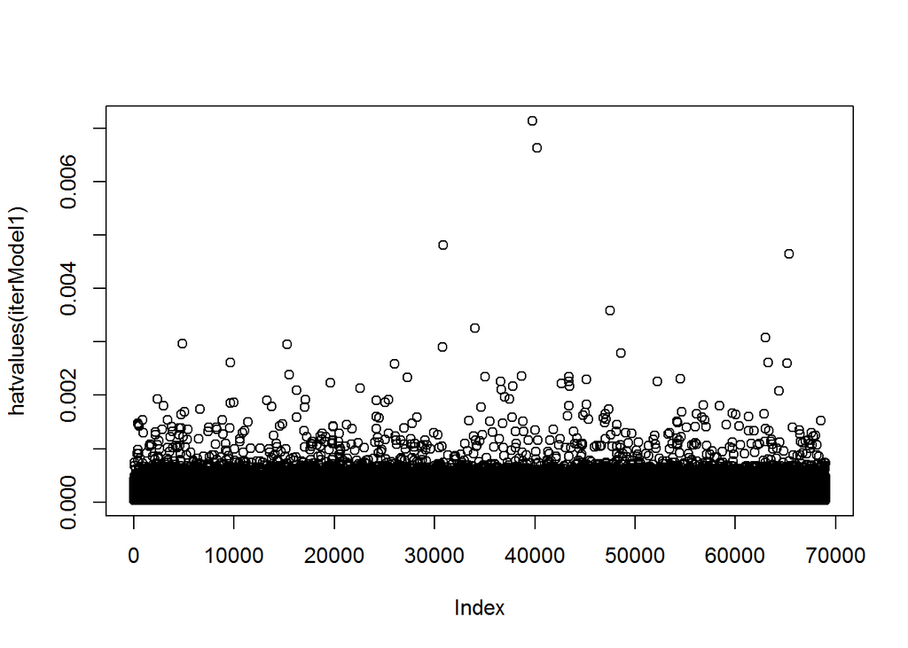

```r
plot(hatvalues(iterModel1))
```

Now we will verify for confounding variables.

```r
iterModel2 = lm(cardio_train_clean$cardio ~
                 age +
                 gender +
                 height +
                 weight +
                 ap_hi +
                 ap_lo +
                 cholesterol +
                 gluc +
                 smoke +
                 alco +
                 active,
               data = cardio_train_clean
               )
iterModel2
```

```
##
## Call:
## lm(formula = cardio_train_clean$cardio ~ age + gender + height +
##     weight + ap_hi + ap_lo + cholesterol + gluc + smoke + alco +
##     active, data = cardio_train_clean)
##
## Coefficients:
##  (Intercept)           age        gender        height        weight
##   -1.458e+00     2.961e-05    -1.366e-03    -9.458e-04     2.393e-03
##        ap_hi         ap_lo  cholesterol2  cholesterol3         gluc2
##    7.550e-03     5.047e-03     8.443e-02     2.091e-01     2.079e-03
##        gluc3         smoke          alco        active
##   -5.746e-02    -2.630e-02    -4.044e-02    -4.443e-02
```

```r
anova(iterModel2)
```

```
## Analysis of Variance Table
##
## Response: cardio_train_clean$cardio
##                Df  Sum Sq Mean Sq   F value    Pr(>F)
## age             1   991.3  991.26 5067.2790 < 2.2e-16 ***
## gender          1     2.9    2.95   15.0714 0.0001036 ***
## height          1     0.1    0.14    0.7186 0.3966086
## weight          1   510.5  510.51 2609.7178 < 2.2e-16 ***
## ap_hi           1  1850.2 1850.24 9458.3717 < 2.2e-16 ***
## ap_lo           1   109.9  109.94  562.0081 < 2.2e-16 ***
## cholesterol     2   242.5  121.26  619.8545 < 2.2e-16 ***
## gluc            2    11.7    5.87   29.9837 9.636e-14 ***
## smoke           1     7.1    7.09   36.2552 1.740e-09 ***
## alco            1     5.4    5.41   27.6447 1.462e-07 ***
## active          1    21.5   21.48  109.8001 < 2.2e-16 ***
## Residuals   68987 13495.2    0.20
## ---
## Signif. codes:  0 '***' 0.001 '**' 0.01 '*' 0.05 '.' 0.1 ' ' 1
```

```r
anova(iterModel1,iterModel2)
```

```
## Analysis of Variance Table
##
## Model 1: cardio_train_clean$cardio ~ age + gender + weight + ap_hi + ap_lo +
##     cholesterol + gluc + smoke + alco + active
## Model 2: cardio_train_clean$cardio ~ age + gender + height + weight +
##     ap_hi + ap_lo + cholesterol + gluc + smoke + alco + active
##   Res.Df   RSS Df Sum of Sq      F    Pr(>F)
## 1  68988 13498
## 2  68987 13495  1    2.8769 14.707 0.0001257 ***
## ---
## Signif. codes:  0 '***' 0.001 '**' 0.01 '*' 0.05 '.' 0.1 ' ' 1
```

Some of the values changed significantly and as such height is a confounding variable.  
Therefore it will be added back into the model.

v)

```r
cardio_train_lowCol = cardio_train_clean[which(cardio_train_clean$cholesterol==1),]
cardio_train_medCol = cardio_train_clean[which(cardio_train_clean$cholesterol==2),]
cardio_train_highCol = cardio_train_clean[which(cardio_train_clean$cholesterol==3),]
lowColModel = lm(cardio_train_lowCol$cardio ~
                 age +
                 gender +
                 height +
                 weight +
                 ap_hi +
                 ap_lo +
                 gluc +
                 smoke +
                 alco +
                 active,
               data = cardio_train_lowCol
               )
lowColModel
```

```
##
## Call:
## lm(formula = cardio_train_lowCol$cardio ~ age + gender + height +
##     weight + ap_hi + ap_lo + gluc + smoke + alco + active, data = cardio_train_lowCol)
##
## Coefficients:
## (Intercept)          age       gender       height       weight
##  -1.6311076    0.0000325   -0.0017775   -0.0011784    0.0025470
##       ap_hi        ap_lo        gluc2        gluc3        smoke
##   0.0083908    0.0055775    0.0393670   -0.0156985   -0.0364284
##        alco       active
##  -0.0365697   -0.0507487
```

```r
medCol = lm(cardio_train_medCol$cardio ~
                 age +
                 gender +
                 height +
                 weight +
                 ap_hi +
                 ap_lo +
                 gluc +
                 smoke +
                 alco +
                 active,
               data = cardio_train_medCol
               )
medCol
```

```
##
## Call:
## lm(formula = cardio_train_medCol$cardio ~ age + gender + height +
##     weight + ap_hi + ap_lo + gluc + smoke + alco + active, data = cardio_train_medCol)
##
## Coefficients:
## (Intercept)          age       gender       height       weight
##  -1.195e+00    1.532e-05    7.526e-03    1.339e-04    1.903e-03
##       ap_hi        ap_lo        gluc2        gluc3        smoke
##   7.193e-03    5.260e-03   -2.951e-02   -4.731e-02   -1.558e-02
##        alco       active
##  -7.206e-02   -4.869e-02
```

```r
highCol = lm(cardio_train_highCol$cardio ~
                 age +
                 gender +
                 height +
                 weight +
                 ap_hi +
                 ap_lo +
                 gluc +
                 smoke +
                 alco +
                 active,
               data = cardio_train_highCol
               )
highCol
```

```
##
## Call:
## lm(formula = cardio_train_highCol$cardio ~ age + gender + height +
##     weight + ap_hi + ap_lo + gluc + smoke + alco + active, data = cardio_train_highCol)
##
## Coefficients:
## (Intercept)          age       gender       height       weight
##   0.0384302    0.0000154   -0.0227982   -0.0010475    0.0018135
##       ap_hi        ap_lo        gluc2        gluc3        smoke
##   0.0027647    0.0014095   -0.0366686   -0.1166188    0.0110810
##        alco       active
##   0.0005501    0.0082072
```

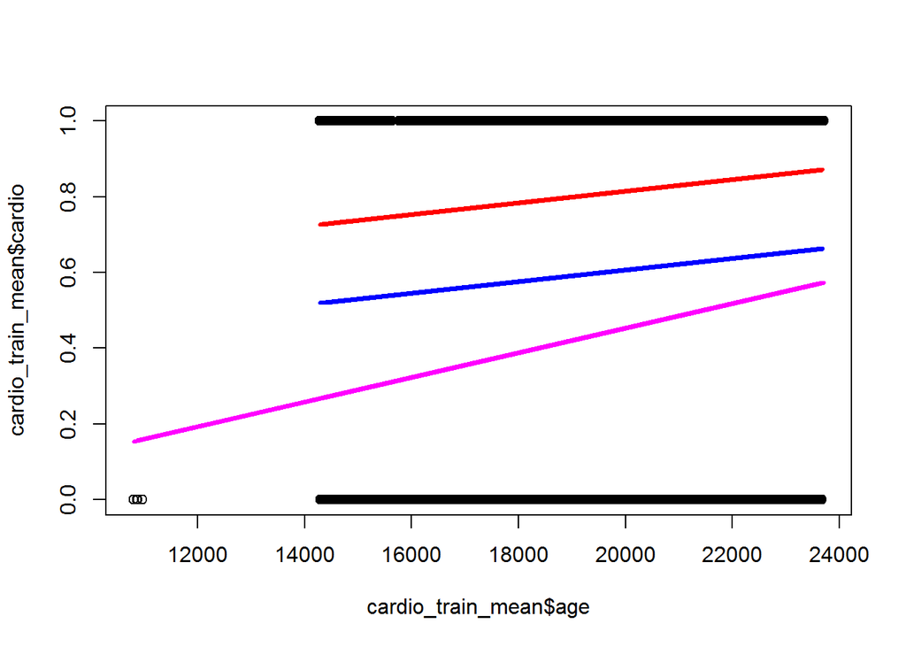

```r
calculate_mode <- function(x) {
  uniqx <- unique(na.omit(x))
  uniqx[which.max(tabulate(match(x, uniqx)))]
}

cardio_train_mean = cardio_train_lowCol
cardio_train_mean$gender = calculate_mode(cardio_train_lowCol$gender)
cardio_train_mean$height = mean(cardio_train_lowCol$height)
cardio_train_mean$weight = mean(cardio_train_lowCol$weight)
cardio_train_mean$ap_hi = mean(cardio_train_lowCol$ap_hi)
cardio_train_mean$ap_lo = mean(cardio_train_lowCol$ap_lo)
cardio_train_mean$smoke = calculate_mode(cardio_train_lowCol$smoke)
cardio_train_mean$alco = calculate_mode(cardio_train_lowCol$alco)
cardio_train_mean$active = calculate_mode(cardio_train_lowCol$active)
cardio_train_mean$cholesterol = calculate_mode(cardio_train_lowCol$cholesterol)
cardio_train_mean$gluc = calculate_mode(cardio_train_lowCol$gluc)

s = cardio_train_lowCol
cardio_train_lowCol = cardio_train_mean

plot(cardio_train_mean$age,cardio_train_mean$cardio)
pr1 <- predict(lowColModel, cardio_train_lowCol, interval="confidence")
yhat <- pr1[,1]
lines(cardio_train_lowCol$age, yhat, lwd=3, lty=1, col="magenta")

cardio_train_lowCol = s

cardio_train_mean = cardio_train_medCol
cardio_train_mean$gender = calculate_mode(cardio_train_medCol$gender)
cardio_train_mean$height = mean(cardio_train_medCol$height)
cardio_train_mean$weight = mean(cardio_train_medCol$weight)
cardio_train_mean$ap_hi = mean(cardio_train_medCol$ap_hi)
cardio_train_mean$ap_lo = mean(cardio_train_medCol$ap_lo)
cardio_train_mean$smoke = calculate_mode(cardio_train_medCol$smoke)
cardio_train_mean$alco = calculate_mode(cardio_train_medCol$alco)
cardio_train_mean$active = calculate_mode(cardio_train_medCol$active)
cardio_train_mean$cholesterol = calculate_mode(cardio_train_medCol$cholesterol)
cardio_train_mean$gluc = calculate_mode(cardio_train_medCol$gluc)

s = cardio_train_medCol
cardio_train_medCol = cardio_train_mean

pr1 <- predict(medCol, cardio_train_medCol, interval="confidence")
yhat <- pr1[,1]
lines(cardio_train_medCol$age, yhat, lwd=3, lty=1, col="blue")

cardio_train_medCol = s

cardio_train_mean = cardio_train_highCol
cardio_train_mean$gender = calculate_mode(cardio_train_highCol$gender)
cardio_train_mean$height = mean(cardio_train_highCol$height)
cardio_train_mean$weight = mean(cardio_train_highCol$weight)
cardio_train_mean$ap_hi = mean(cardio_train_highCol$ap_hi)
cardio_train_mean$ap_lo = mean(cardio_train_highCol$ap_lo)
cardio_train_mean$smoke = calculate_mode(cardio_train_highCol$smoke)
cardio_train_mean$alco = calculate_mode(cardio_train_highCol$alco)
cardio_train_mean$active = calculate_mode(cardio_train_highCol$active)
cardio_train_mean$cholesterol = calculate_mode(cardio_train_highCol$cholesterol)
cardio_train_mean$gluc = calculate_mode(cardio_train_highCol$gluc)

s = cardio_train_highCol
cardio_train_highCol = cardio_train_mean

pr1 <- predict(highCol, cardio_train_highCol, interval="confidence")
yhat <- pr1[,1]
lines(cardio_train_highCol$age, yhat, lwd=3, lty=1, col="red")
```

```r
cardio_train_highCol = s
```

Let’s now change our model to include that iteraction.

```r
ageColModel = lm(cardio_train_clean$cardio ~
                 age*
                 cholesterol  +
                 gender +
                 height +
                 weight +
                 ap_hi +
                 ap_lo +
                 gluc +
                 smoke +
                 alco +
                 active,
               data = cardio_train_clean
               )
ageColModel
```

```
##
## Call:
## lm(formula = cardio_train_clean$cardio ~ age * cholesterol +
##     gender + height + weight + ap_hi + ap_lo + gluc + smoke +
##     alco + active, data = cardio_train_clean)
##
## Coefficients:
##      (Intercept)               age      cholesterol2      cholesterol3
##       -1.532e+00         3.421e-05         4.711e-01         6.645e-01
##           gender            height            weight             ap_hi
##       -9.441e-04        -1.008e-03         2.379e-03         7.560e-03
##            ap_lo             gluc2             gluc3             smoke
##        4.989e-03         2.775e-03        -5.873e-02        -2.653e-02
##             alco            active  age:cholesterol2  age:cholesterol3
##       -4.036e-02        -4.461e-02        -1.980e-05        -2.243e-05
```

```r
anova(ageColModel)
```

```
## Analysis of Variance Table
##
## Response: cardio_train_clean$cardio
##                    Df  Sum Sq Mean Sq   F value    Pr(>F)
## age                 1   991.3  991.26 5078.6700 < 2.2e-16 ***
## cholesterol         2   600.0  300.02 1537.1243 < 2.2e-16 ***
## gender              1     6.5    6.47   33.1508 8.564e-09 ***
## height              1     1.0    1.00    5.1211   0.02364 *
## weight              1   363.1  363.05 1860.0746 < 2.2e-16 ***
## ap_hi               1  1647.0 1646.98 8438.2209 < 2.2e-16 ***
## ap_lo               1    98.8   98.76  505.9947 < 2.2e-16 ***
## gluc                2    11.7    5.87   30.0511 9.009e-14 ***
## smoke               1     7.1    7.09   36.3367 1.668e-09 ***
## alco                1     5.4    5.41   27.7068 1.416e-07 ***
## active              1    21.5   21.48  110.0470 < 2.2e-16 ***
## age:cholesterol     2    30.7   15.33   78.5397 < 2.2e-16 ***
## Residuals       68985 13464.5    0.20
## ---
## Signif. codes:  0 '***' 0.001 '**' 0.01 '*' 0.05 '.' 0.1 ' ' 1
```

```r
anova(iterModel2,ageColModel)
```

```
## Analysis of Variance Table
##
## Model 1: cardio_train_clean$cardio ~ age + gender + height + weight +
##     ap_hi + ap_lo + cholesterol + gluc + smoke + alco + active
## Model 2: cardio_train_clean$cardio ~ age * cholesterol + gender + height +
##     weight + ap_hi + ap_lo + gluc + smoke + alco + active
##   Res.Df   RSS Df Sum of Sq     F    Pr(>F)
## 1  68987 13495
## 2  68985 13464  2    30.659 78.54 < 2.2e-16 ***
## ---
## Signif. codes:  0 '***' 0.001 '**' 0.01 '*' 0.05 '.' 0.1 ' ' 1
```

The coefficients proved to be significant, proving our hypotesis.

## Residuals

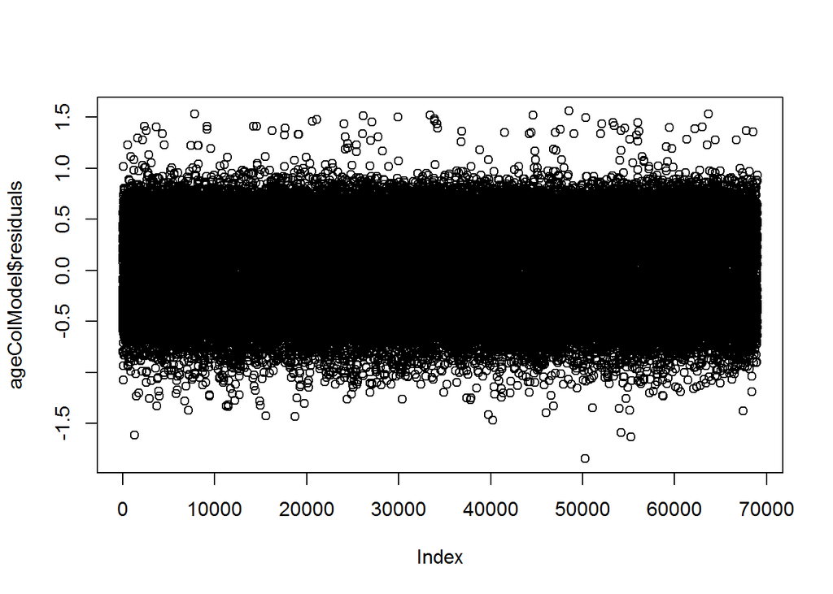

```r
plot(ageColModel$residuals)
```

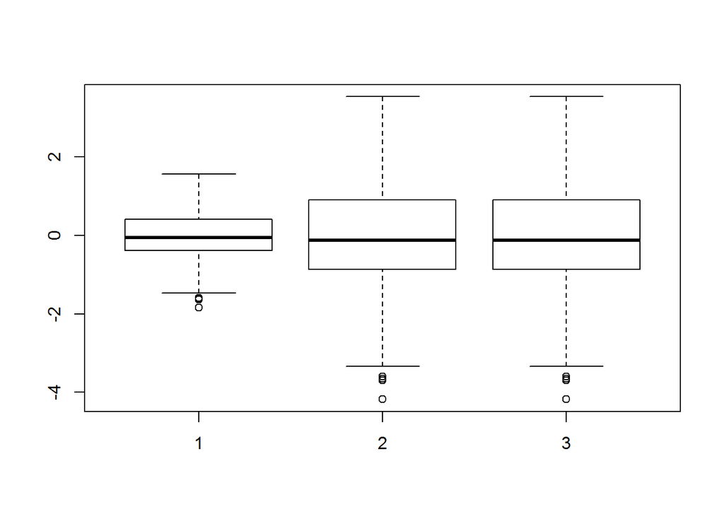

```r
boxplot(ageColModel$residuals,rstandard(ageColModel),rstudent(ageColModel))
```

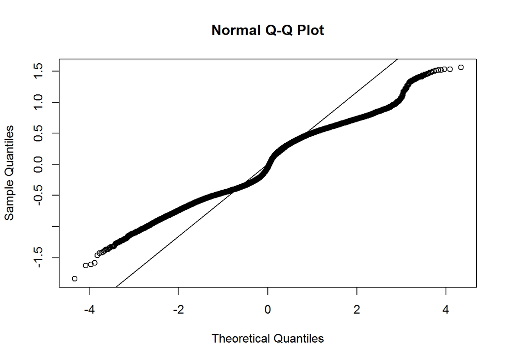

```r
qqnorm(ageColModel$residuals)
qqline(ageColModel$residuals)
```

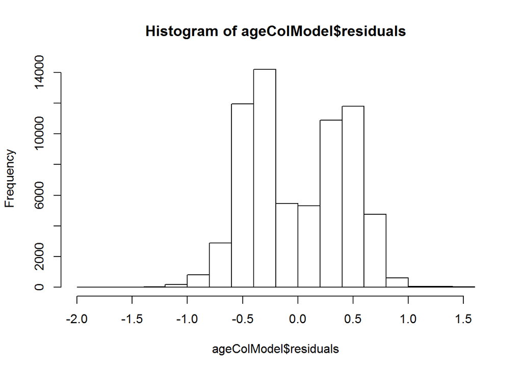

```r
hist(ageColModel$residuals)
```

From the plot the residuals seem to have homocedasticy, however from the normality plots  
we conclude that they are not normal, presenting a wave like pattern.

## Further analisis of two variables

i)  
continuous variable: age  
categorical variable: cholesterol

Gross effects:  
age - 0.00004855  
cholesterol_2 - 0.1609  
cholesterol_3 - 0.3272  
Adjusted efffects:  
age - 0.00003421  
cholesterol2 - 0.4711  
cholesterol3 - 0.6645

ii)

```r
releveledCholesterol = relevel(cardio_train_clean$cholesterol,ref="3")
cholConfintModel = lm(cardio_train_clean$cardio ~
                 age *
                 releveledCholesterol  +
                 gender +
                 height +
                 weight +
                 ap_hi +
                 ap_lo +
                 gluc +
                 smoke +
                 alco +
                 active,
               data = cardio_train_clean
               )
cholConfintModel
```

```
##
## Call:
## lm(formula = cardio_train_clean$cardio ~ age * releveledCholesterol +
##     gender + height + weight + ap_hi + ap_lo + gluc + smoke +
##     alco + active, data = cardio_train_clean)
##
## Coefficients:
##               (Intercept)                        age
##                -8.676e-01                  1.177e-05
##     releveledCholesterol1      releveledCholesterol2
##                -6.645e-01                 -1.934e-01
##                    gender                     height
##                -9.441e-04                 -1.008e-03
##                    weight                      ap_hi
##                 2.379e-03                  7.560e-03
##                     ap_lo                      gluc2
##                 4.989e-03                  2.775e-03
##                     gluc3                      smoke
##                -5.873e-02                 -2.653e-02
##                      alco                     active
##                -4.036e-02                 -4.461e-02
## age:releveledCholesterol1  age:releveledCholesterol2
##                 2.243e-05                  2.634e-06
```

```r
confint(cholConfintModel, 'releveledCholesterol2', level=0.95)
```

```
##                            2.5 %      97.5 %
## releveledCholesterol2 -0.3132855 -0.07350826
```

```r
confint(cholConfintModel, 'releveledCholesterol2', level=0.90)
```

```
##                              5 %        95 %
## releveledCholesterol2 -0.2940101 -0.09278359
```

The 95% interval for the change is [-0.3132855,-0.07350826].  
The 90% interval for the change is [-0.294010,-0.09278359].  
Meaning that there is about a 7-31% decrease in the chance of cardiovascular disease when  
going from the 3rd category to the 2nd one.

iv)

```r
sdAge = sd(cardio_train_clean$age)
coefAge = ageColModel$coefficients[2]
change = sdAge*coefAge
change
```

```
##        age
## 0.08442609
```